# MECH476: Engineering Data Analysis in R

Chapter 6 Homework: Strings, Dates, and Tidying

Vance Petersen

16 October, 2025

# Chapter 6 Homework

For this homework assignment, you will use data from Twitter that include tweets (2011 to 2017) from Colorado senators, which can be downloaded from Canvas. Just FYI—some tweets were cut off before Twitter’s character limit; just work with the data you have. The original data are from [FiveThirtyEight](https://github.com/fivethirtyeight/data/tree/master/twitter-ratio).

When a question asks you to make a plot, remember to set a theme, title, subtitle, labels, colors, etc. It is up to you how to personalize your plots, but put in some effort and think about making the plotting approach consistent throughout the document. For example, you could use the same theme for all plots. I also like to use the subtitle as a place for the main summary for the viewer.

## Question 1: Hashtags

Within a pipeline using the Colorado-only tweet data, select `text` variable and use `stringr::str_extract_all()` with a pattern of `"#(\\d|\\w)+"` to extract all of the hashtags from the tweets. This will return a list with one element. How many hashtags were used by Colorado senators?

```r
# wildfire hashtag list

hashtags <- stringr::str_extract_all(string = (senators$text), pattern = "#(\\d|\\w)+")
head(hashtags)
```

```
## [[1]]
## character(0)
##
## [[2]]
## character(0)
##
## [[3]]
## character(0)
##
## [[4]]
## [1] "#Arctic" "#budget"
##
## [[5]]
## [1] "#AlexanderMurray"
##
## [[6]]
## character(0)
```

## Question 2: Fires

Colorado is on fire right now and has experienced many wildfires over the years. Let’s examine senators’ tweet activity related to wildfires based on hashtags. Using the character vector of hashtags you extracted in Question 1, search for the hashtags that include “fire” or “wildfire”. How many hashtags included “fire”? How many included “wildfire”?

```r
stringr::str_detect(string = (unlist(hashtags)), pattern = "fire|wildfire") %>% sum()
```

```
## [1] 16
```

```r
stringr::str_detect(string = (hashtags), pattern = "wildfire") %>% sum()
```

```
## [1] 8
```

```r
stringr::str_detect(string = (hashtags), pattern = "fire") %>% sum()
```

```
## [1] 16
```

- 16 total tweets include “fire” and “wildfire”
- 16 tweets include “fire”
- 8 tweets include “wildfire”

## Question 3: Wildfires

Now, let’s look at general tweets concerning wildfires. First, subset the data to a dataframe that includes tweets containing the word “wildfire” and their corresponding timestamp and user. Specifically, (a) select `text`, `date`, and `user` and (b) filter to text strings that include the word “wildfire” using `dplyr::filter()` and `stringr::str_detect()`.

```r
# filter to tweets concerning wildfires

fire_twt <- senators %>% filter(str_detect(text, "wildfire")) %>% select(text, created_at, user)
head(fire_twt)
```

```
##                                                                                                                                               text
## 1 Intro'd bill to help #wildfire recovery &amp; prevention efforts with @MikeCrapo @SenatorTester @SenatorRisch @RonWyden: https://t.co/9KikC50oF3
## 2       Tune in to watch @USDA @forestservice briefing on fixing #wildfire funding. More on our legislation here:\xe4\xf3_ https://t.co/ELt4I5hX6U
## 3        As #opioid addiction rips through Colorado &amp; the country like wildfire, #Trumpcare would only fan the flames: https://t.co/BUR6D6565c
## 4                Our thoughts and sympathies are with all of the families affected by the wildfires now burning across the state #COFire #COStatus
## 5        Glad to see our wildfire mitigation provision, the Good Neighbor Authority, is being implemented by @forestservice http://t.co/6lUsquowTK
## 6      #TBT to speaking with the brave firefighters from @forestservice. They help keep our communities safe from wildfires http://t.co/IlzYQFLnJn
##      created_at        user
## 1 10/6/17 17:26 SenBennetCO
## 2 9/26/17 19:02 SenBennetCO
## 3  7/5/17 19:00 SenBennetCO
## 4 7/12/16 20:05 SenBennetCO
## 5  8/6/15 22:45 SenBennetCO
## 6 6/11/15 21:25 SenBennetCO
```

## Question 4: Senators

Which Colorado senator tweets more about wildfires?

```r
# number of wildfire tweets by senator
str_detect(fire_twt, pattern = "SenBennetCO") %>% sum() > str_detect(fire_twt, pattern = "SenCoryGardnger") %>% sum()
```

```
## [1] TRUE
```

## Question 5: Timing

Using the same `wildfires` dataframe, create a summary table that shows the number of tweets containing the word “wildfire” by year (2011-2017). Which year has the most tweets about wildfires? Why might this be the case? (Hint: Think about what happened in the previous year.)

```r
# number of wildfire tweets by year
fire_twt %>% mutate(date = mdy_hm(created_at), year = year(date)) %>% filter(year >= 2011 & year <= 2017) %>% count(year, name = "number of tweets")
```

```
##   year number of tweets
## 1 2011                2
## 2 2012                3
## 3 2013               13
## 4 2014                1
## 5 2015                6
## 6 2016                5
## 7 2017                3
```

## Question 6: Monthly tweets

Create a bar chart that answers the question: Are Colorado senators more active at a certain time of year? Hints: Convert `month` to a factor. Fill by `user`.

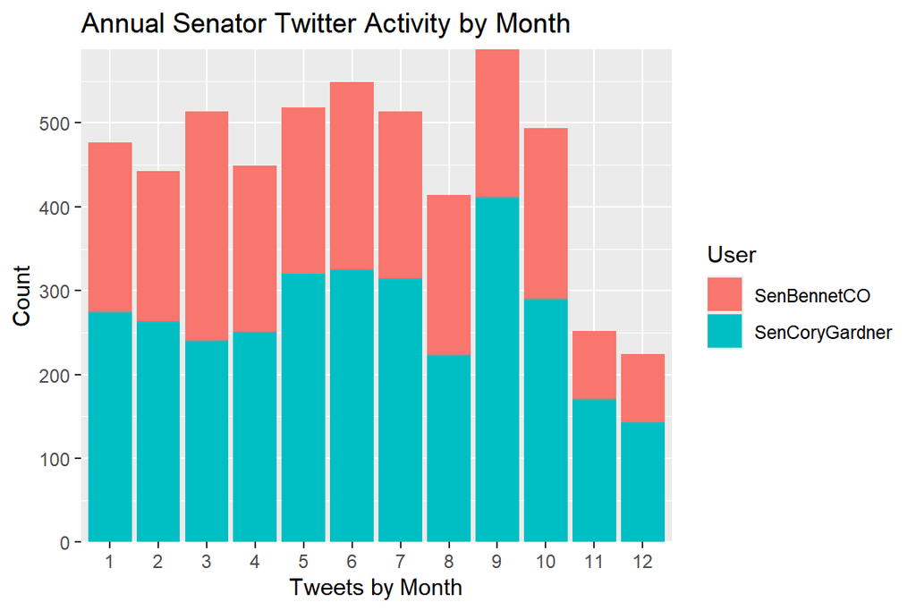

```r
# create plot of tweets by month and user

senators %>% mutate(date = mdy_hm(created_at), month = factor(month(date), levels = 1:12)) %>% ggplot(aes(x = month, fill = user)) + geom_bar() + labs(x = "Tweets by Month", y = "Count", fill = "User", title = "Annual Senator Twitter Activity by Month") + scale_y_continuous(expand = c(0,NA))
```

## Question 7: Hourly tweets

Create a histogram of tweets by hour of day to visualize when our senators are tweeting.

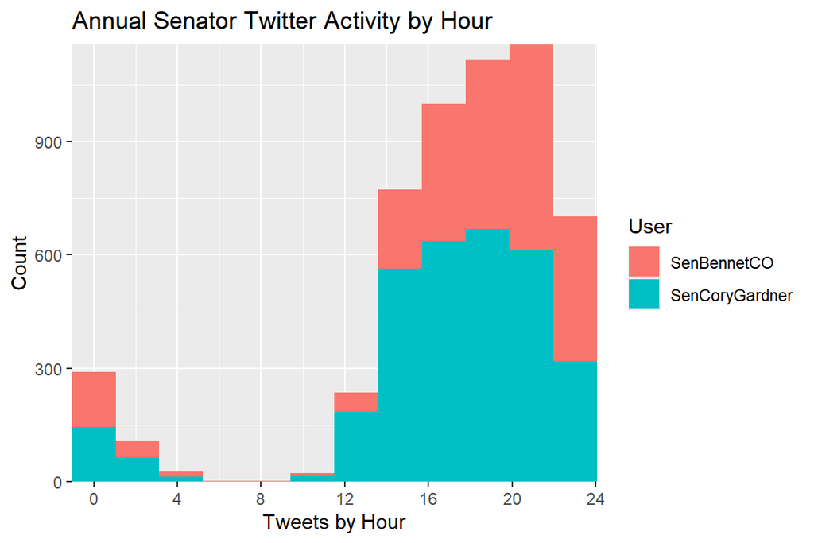

```r
# create plot of cumulative hourly tweets by senator

senators %>% mutate(date = mdy_hm(created_at), hour = hour(date)) %>% ggplot(aes(x = hour, fill = user)) + geom_histogram(bins = 12) + labs(x = "Tweets by Hour", y = "Count", fill = "User", title = "Annual Senator Twitter Activity by Hour") + scale_y_continuous(expand = c(0,NA)) + scale_x_continuous(expand = c(0, NA), breaks = seq(0, 24, by = 4))
```

# Appendix

```r
# set global options for figures, code, warnings, and messages
knitr::opts_chunk$set(fig.width=6, fig.height=4, fig.path="../figs/",
                      echo=TRUE, warning=FALSE, message=TRUE)
senators <- read.csv("../data/senators_co (1).csv")
library("tidyverse")

# wildfire hashtag list

hashtags <- stringr::str_extract_all(string = (senators$text), pattern = "#(\\d|\\w)+")
head(hashtags)

stringr::str_detect(string = (unlist(hashtags)), pattern = "fire|wildfire") %>% sum()

stringr::str_detect(string = (hashtags), pattern = "wildfire") %>% sum()
stringr::str_detect(string = (hashtags), pattern = "fire") %>% sum()

# filter to tweets concerning wildfires

fire_twt <- senators %>% filter(str_detect(text, "wildfire")) %>% select(text, created_at, user)
head(fire_twt)

# number of wildfire tweets by senator
str_detect(fire_twt, pattern = "SenBennetCO") %>% sum() > str_detect(fire_twt, pattern = "SenCoryGardnger") %>% sum()

# number of wildfire tweets by year
fire_twt %>% mutate(date = mdy_hm(created_at), year = year(date)) %>% filter(year >= 2011 & year <= 2017) %>% count(year, name = "number of tweets")

# create plot of tweets by month and user

senators %>% mutate(date = mdy_hm(created_at), month = factor(month(date), levels = 1:12)) %>% ggplot(aes(x = month, fill = user)) + geom_bar() + labs(x = "Tweets by Month", y = "Count", fill = "User", title = "Annual Senator Twitter Activity by Month") + scale_y_continuous(expand = c(0,NA))

# create plot of cumulative hourly tweets by senator

senators %>% mutate(date = mdy_hm(created_at), hour = hour(date)) %>% ggplot(aes(x = hour, fill = user)) + geom_histogram(bins = 12) + labs(x = "Tweets by Hour", y = "Count", fill = "User", title = "Annual Senator Twitter Activity by Hour") + scale_y_continuous(expand = c(0,NA)) + scale_x_continuous(expand = c(0, NA), breaks = seq(0, 24, by = 4))
```